# R Notebook

```r
path = 'heart.CSV'
heartData <- read.csv(path, row.names=NULL)
```

```r
path = 'o2Saturation.csv'
saturationData <- read.csv(path, row.names=NULL)
```

```r
print('NA')
```

```
## [1] "NA"
```

```r
colSums(is.na(heartData))
```

```
##      age      sex       cp   trtbps     chol      fbs  restecg thalachh
##        0        0        0        0        0        0        0        0
##     exng  oldpeak      slp      caa    thall   output
##        0        0        0        0        0        0
```

```r
print('Blancs')
```

```
## [1] "Blancs"
```

```r
colSums(heartData=="")
```

```
##      age      sex       cp   trtbps     chol      fbs  restecg thalachh
##        0        0        0        0        0        0        0        0
##     exng  oldpeak      slp      caa    thall   output
##        0        0        0        0        0        0
```

```r
print('Zeros')
```

```
## [1] "Zeros"
```

```r
colSums(heartData=="0")
```

```
##      age      sex       cp   trtbps     chol      fbs  restecg thalachh
##        0       96      143        0        0      258      147        0
##     exng  oldpeak      slp      caa    thall   output
##      204       99       21      175        2      138
```

```r
print('Unknown')
```

```
## [1] "Unknown"
```

```r
colSums(heartData=="Unknown")
```

```
##      age      sex       cp   trtbps     chol      fbs  restecg thalachh
##        0        0        0        0        0        0        0        0
##     exng  oldpeak      slp      caa    thall   output
##        0        0        0        0        0        0
```

```r
print('None')
```

```
## [1] "None"
```

```r
colSums(heartData=="None")
```

```
##      age      sex       cp   trtbps     chol      fbs  restecg thalachh
##        0        0        0        0        0        0        0        0
##     exng  oldpeak      slp      caa    thall   output
##        0        0        0        0        0        0
```

```r
if (!require('ggplot2')) install.packages('ggplot2'); library('ggplot2')
if(!require('Rmisc')) install.packages('Rmisc'); library('Rmisc')
if(!require('dplyr')) install.packages('dplyr'); library('dplyr')
if(!require('xfun')) install.packages('xfun'); library('xfun')
if(!require('gridExtra')) install.packages('gridExtra'); library('gridExtra')

summary(heartData[c("chol")])
```

```
##       chol
##  Min.   :126.0
##  1st Qu.:211.0
##  Median :240.0
##  Mean   :246.3
##  3rd Qu.:274.5
##  Max.   :564.0
```

```r
histList<- list()

df1 <- heartData %>%
  group_by(heartData$chol) %>%
  dplyr::summarise(counts = n())
df1
```

| heartData$chol | counts |
| --- | --- |
| 126 | 1 |
| 131 | 1 |
| 141 | 1 |
| 149 | 2 |
| 157 | 1 |
| 160 | 1 |
| 164 | 1 |
| 166 | 1 |
| 167 | 1 |
| 168 | 1 |

[output cut: 142 more lines]

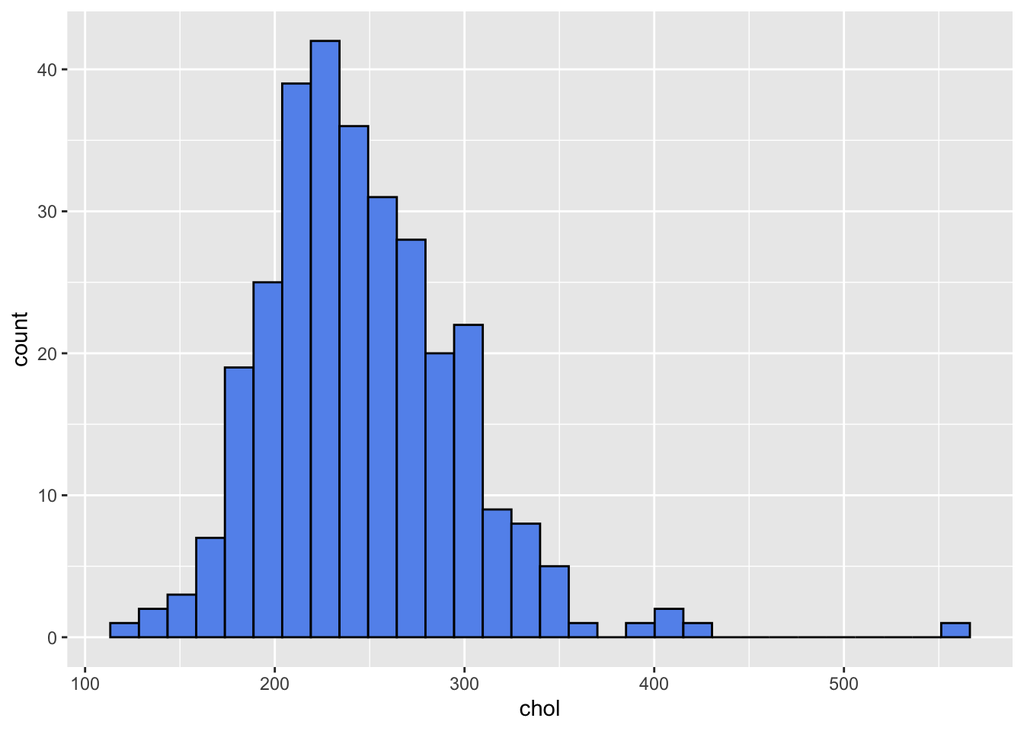

```r
n = c("chol")
heartDataAux = heartData %>% select(all_of(n))
for(i in 1:ncol(heartDataAux)){
  col <- names(heartDataAux)[i]
  ggp <- ggplot(heartDataAux, aes_string(x = col)) +
    geom_histogram(bins = 30, fill = "cornflowerblue", color = "black",ggtittle = "Comptador d'ocurrències per variable")
      histList[[i]] <- ggp  # afegim cada plot a la llista buida
}
 multiplot(plotlist = histList, cols = 1)
```

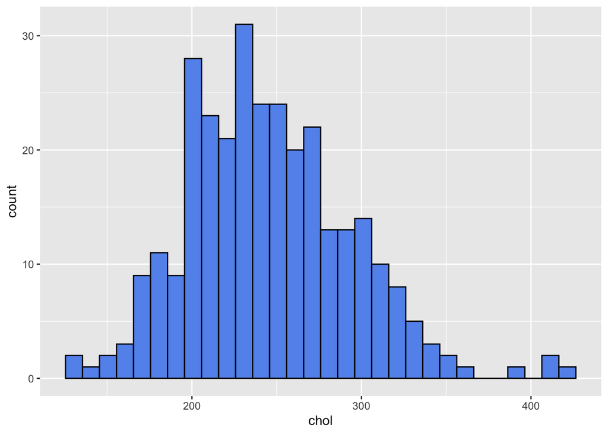

```r
index=1
for(i in heartData$chol){
  if(i == 564){
    heartData$chol[index]= 246.3
  }
   index = index +1
}
n = c("chol")
heartDataAux = heartData %>% select(all_of(n))
for(i in 1:ncol(heartDataAux)){
  col <- names(heartDataAux)[i]
  ggp <- ggplot(heartDataAux, aes_string(x = col)) +
    geom_histogram(bins = 30, fill = "cornflowerblue", color = "black",ggtittle = "Comptador d'ocurrències per variable")
      histList[[i]] <- ggp  # afegim cada plot a la llista buida
}
 multiplot(plotlist = histList, cols = 1)
```

```r
summary(heartData)
```

```
##       age             sex               cp            trtbps
##  Min.   :29.00   Min.   :0.0000   Min.   :0.000   Min.   : 94.0
##  1st Qu.:47.50   1st Qu.:0.0000   1st Qu.:0.000   1st Qu.:120.0
##  Median :55.00   Median :1.0000   Median :1.000   Median :130.0
##  Mean   :54.37   Mean   :0.6832   Mean   :0.967   Mean   :131.6
##  3rd Qu.:61.00   3rd Qu.:1.0000   3rd Qu.:2.000   3rd Qu.:140.0
##  Max.   :77.00   Max.   :1.0000   Max.   :3.000   Max.   :200.0
##       chol            fbs            restecg          thalachh
##  Min.   :126.0   Min.   :0.0000   Min.   :0.0000   Min.   : 71.0
##  1st Qu.:211.0   1st Qu.:0.0000   1st Qu.:0.0000   1st Qu.:133.5
##  Median :240.0   Median :0.0000   Median :1.0000   Median :153.0
##  Mean   :245.2   Mean   :0.1485   Mean   :0.5281   Mean   :149.6
##  3rd Qu.:274.0   3rd Qu.:0.0000   3rd Qu.:1.0000   3rd Qu.:166.0
##  Max.   :417.0   Max.   :1.0000   Max.   :2.0000   Max.   :202.0
##       exng           oldpeak          slp             caa
##  Min.   :0.0000   Min.   :0.00   Min.   :0.000   Min.   :0.0000
##  1st Qu.:0.0000   1st Qu.:0.00   1st Qu.:1.000   1st Qu.:0.0000
##  Median :0.0000   Median :0.80   Median :1.000   Median :0.0000
##  Mean   :0.3267   Mean   :1.04   Mean   :1.399   Mean   :0.7294
##  3rd Qu.:1.0000   3rd Qu.:1.60   3rd Qu.:2.000   3rd Qu.:1.0000
##  Max.   :1.0000   Max.   :6.20   Max.   :2.000   Max.   :4.0000
##      thall           output
##  Min.   :0.000   Min.   :0.0000
##  1st Qu.:2.000   1st Qu.:0.0000
##  Median :2.000   Median :1.0000
##  Mean   :2.314   Mean   :0.5446
##  3rd Qu.:3.000   3rd Qu.:1.0000
##  Max.   :3.000   Max.   :1.0000
```

```r
str(heartData)
```

```
## 'data.frame':    303 obs. of  14 variables:
##  $ age     : int  63 37 41 56 57 57 56 44 52 57 ...
##  $ sex     : int  1 1 0 1 0 1 0 1 1 1 ...
##  $ cp      : int  3 2 1 1 0 0 1 1 2 2 ...
##  $ trtbps  : int  145 130 130 120 120 140 140 120 172 150 ...
##  $ chol    : num  233 250 204 236 354 192 294 263 199 168 ...
##  $ fbs     : int  1 0 0 0 0 0 0 0 1 0 ...
##  $ restecg : int  0 1 0 1 1 1 0 1 1 1 ...
##  $ thalachh: int  150 187 172 178 163 148 153 173 162 174 ...
##  $ exng    : int  0 0 0 0 1 0 0 0 0 0 ...
##  $ oldpeak : num  2.3 3.5 1.4 0.8 0.6 0.4 1.3 0 0.5 1.6 ...
##  $ slp     : int  0 0 2 2 2 1 1 2 2 2 ...
##  $ caa     : int  0 0 0 0 0 0 0 0 0 0 ...
##  $ thall   : int  1 2 2 2 2 1 2 3 3 2 ...
##  $ output  : int  1 1 1 1 1 1 1 1 1 1 ...
```

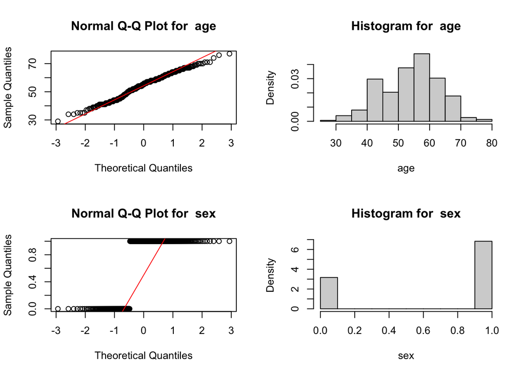

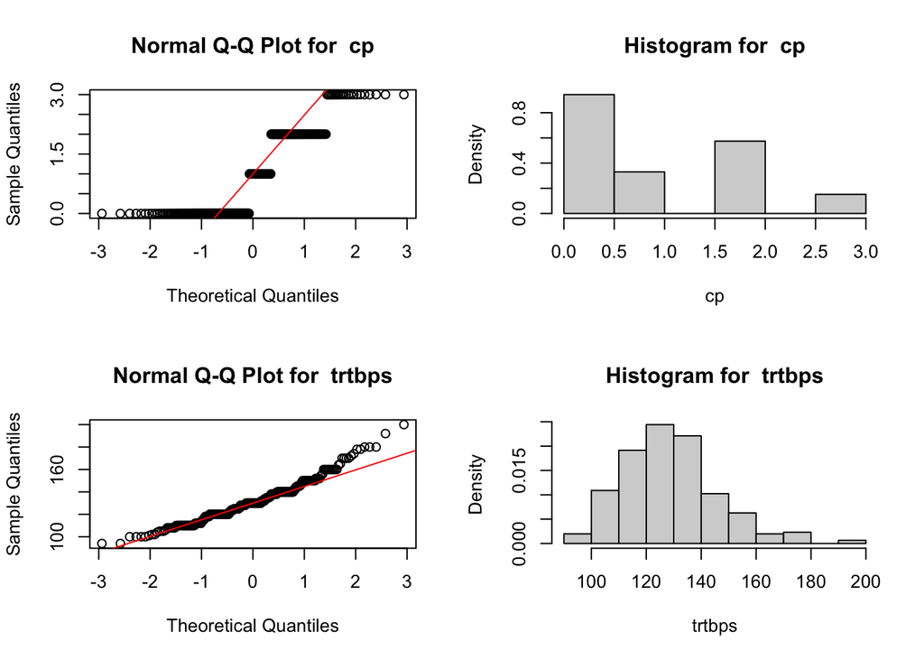

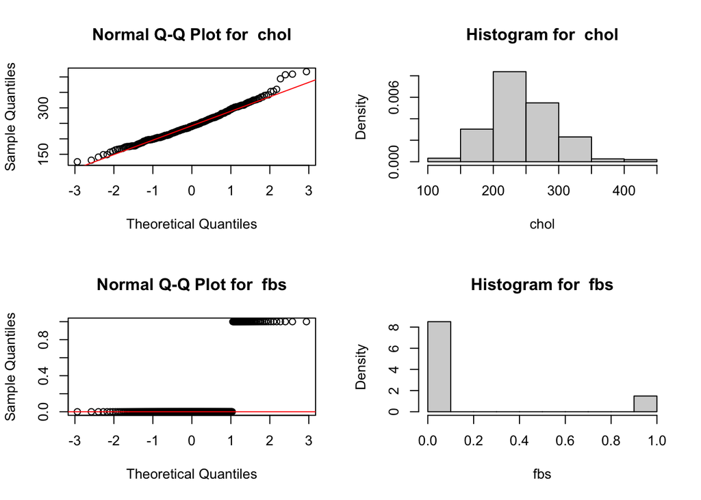

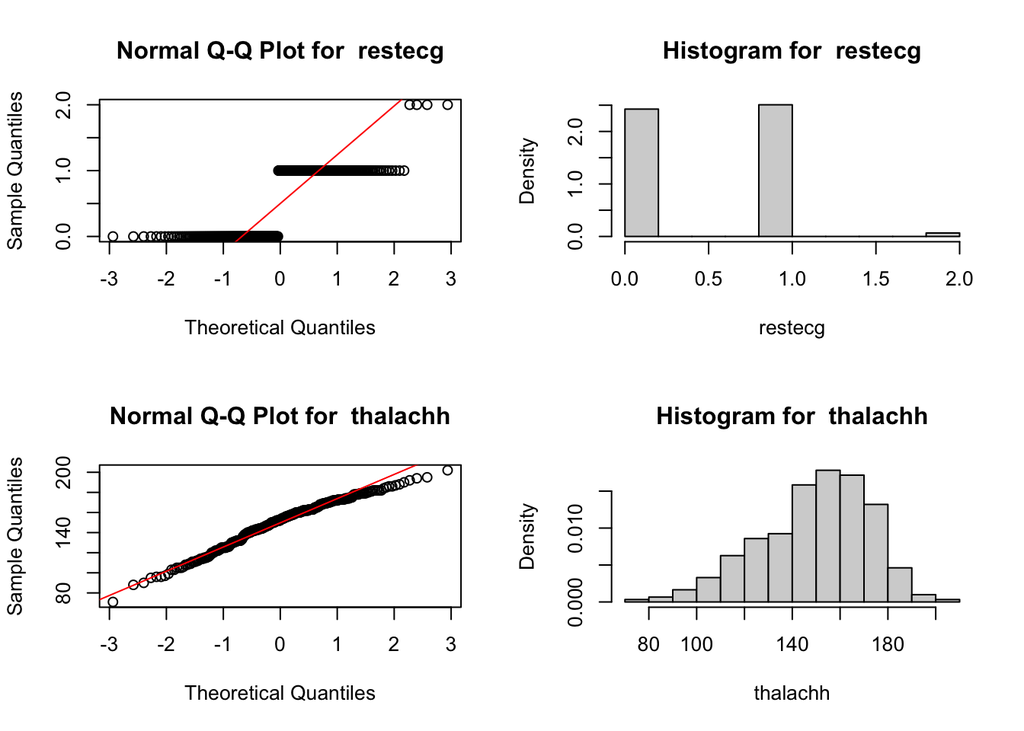

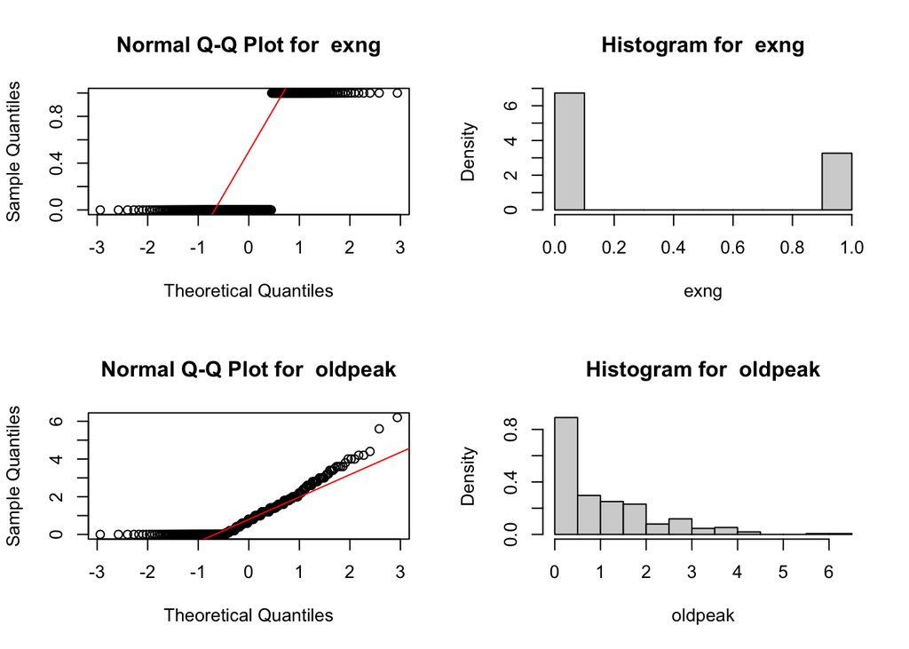

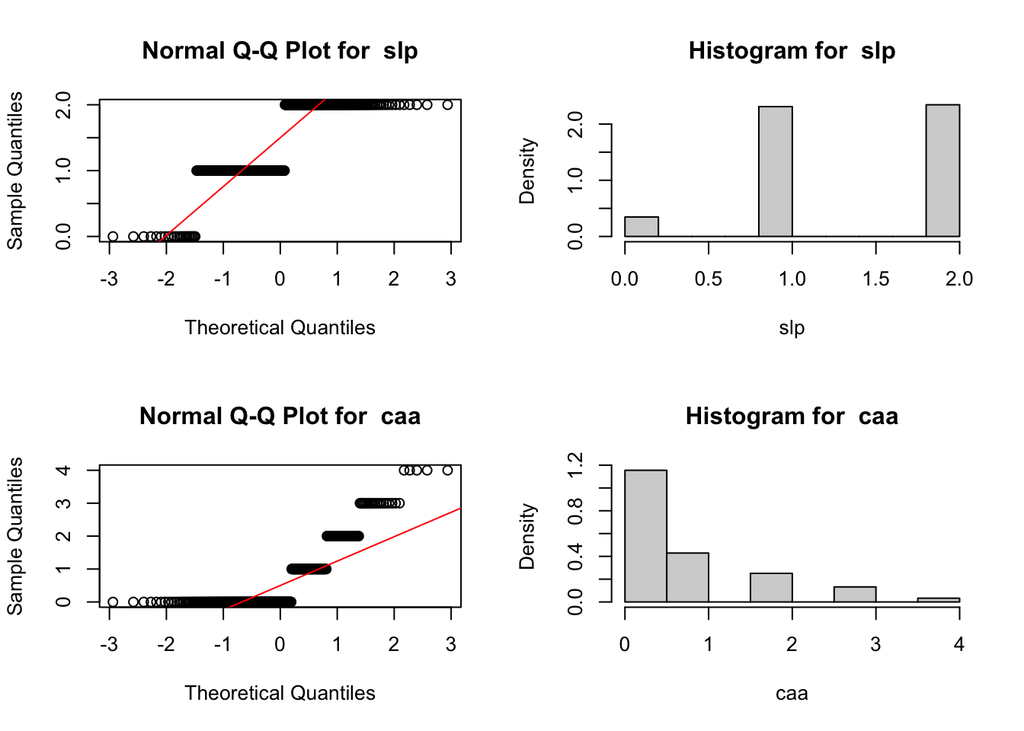

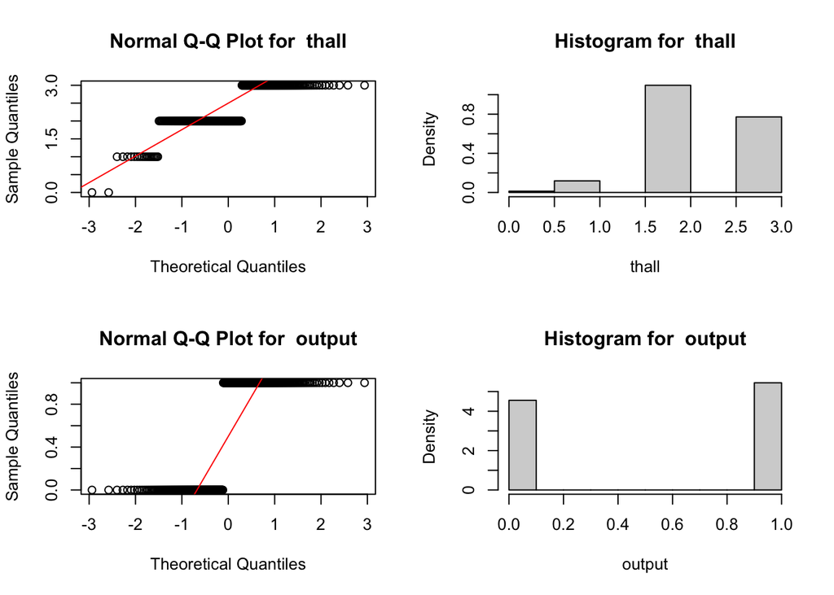

```r
par(mfrow=c(2,2))
for(i in 1:ncol(heartData)) {
  if (is.numeric(heartData[,i])){
    qqnorm(heartData[,i],main = paste("Normal Q-Q Plot for ",colnames(heartData)[i]))
    qqline(heartData[,i],col="red")
    hist(heartData[,i],
      main=paste("Histogram for ", colnames(heartData)[i]),
      xlab=colnames(heartData)[i], freq = FALSE)
  }
}
```

```r
ks.test(heartData$chol, pnorm, mean(heartData$chol), sd(heartData$chol))
```

```
##
##  Asymptotic one-sample Kolmogorov-Smirnov test
##
## data:  heartData$chol
## D = 0.048157, p-value = 0.4833
## alternative hypothesis: two-sided
```

```r
shapiro.test(heartData$chol)
```

```
##
##  Shapiro-Wilk normality test
##
## data:  heartData$chol
## W = 0.98282, p-value = 0.001076
```

En aquest cas s’obtenen resultats diferents per cadascuna de les proves. Mentre que segons Kolmogorov-Smirnov les dades segueixen una distribució normal, el test de Shapiro-Wilk rebutja la hipòtesi nul.la i considera que no és així. Utilitzarem el test de Shapiro-Wilk, j auq es considera un dels mètodes més potents per contrastar la normalitat.

```r
shapiro.test(heartData$age)
```

```
##
##  Shapiro-Wilk normality test
##
## data:  heartData$age
## W = 0.98637, p-value = 0.005798
```

```r
shapiro.test(heartData$sex)
```

```
##
##  Shapiro-Wilk normality test
##
## data:  heartData$sex
## W = 0.58573, p-value < 2.2e-16
```

```r
shapiro.test(heartData$chol)
```

```
##
##  Shapiro-Wilk normality test
##
## data:  heartData$chol
## W = 0.98282, p-value = 0.001076
```

```r
shapiro.test(heartData$cp)
```

```
##
##  Shapiro-Wilk normality test
##
## data:  heartData$cp
## W = 0.79016, p-value < 2.2e-16
```

```r
shapiro.test(heartData$trtbps)
```

```
##
##  Shapiro-Wilk normality test
##
## data:  heartData$trtbps
## W = 0.96592, p-value = 1.458e-06
```

```r
shapiro.test(heartData$fbs)
```

```
##
##  Shapiro-Wilk normality test
##
## data:  heartData$fbs
## W = 0.42399, p-value < 2.2e-16
```

```r
shapiro.test(heartData$restecg)
```

```
##
##  Shapiro-Wilk normality test
##
## data:  heartData$restecg
## W = 0.67932, p-value < 2.2e-16
```

```r
shapiro.test(heartData$thalachh)
```

```
##
##  Shapiro-Wilk normality test
##
## data:  heartData$thalachh
## W = 0.97632, p-value = 6.621e-05
```

```r
shapiro.test(heartData$oldpeak)
```

```
##
##  Shapiro-Wilk normality test
##
## data:  heartData$oldpeak
## W = 0.84418, p-value < 2.2e-16
```

```r
shapiro.test(heartData$thall)
```

```
##
##  Shapiro-Wilk normality test
##
## data:  heartData$thall
## W = 0.75058, p-value < 2.2e-16
```

El test ens indica que cap variable esta normalitzada, ja que el valor p-value és inferior al coeficient 0.05, per tant podem rechazar l’hipotesis i entendre que no segueix una distribució normal.

Tot i així seguint el teorema central del limit com que el nombre de mostres és alt podem aproximan-se a una distribució normal de mitja 0 i desviació estandard 1.

Pel que fa l’homoscedasticitat les proves són el test de Levene quan segueixen una distribució normal i el test Fligner-Killeen quan no compleixen la condició de normalitat.

```r
#install.packages("car")
#library(car)
```

```r
#leveneTest(trtbps ~ chol, data= heartData)
fligner.test(exng ~ sex, data = heartData)
```

```
##
##  Fligner-Killeen test of homogeneity of variances
##
## data:  exng by sex
## Fligner-Killeen:med chi-squared = 6.0607, df = 1, p-value = 0.01382
```

```r
fligner.test(trtbps ~ chol, data = heartData)
```

```
##
##  Fligner-Killeen test of homogeneity of variances
##
## data:  trtbps by chol
## Fligner-Killeen:med chi-squared = 165.73, df = 151, p-value = 0.1949
```

```r
fligner.test(sex ~ cp, data = heartData)
```

```
##
##  Fligner-Killeen test of homogeneity of variances
##
## data:  sex by cp
## Fligner-Killeen:med chi-squared = 6.7996, df = 3, p-value = 0.07857
```

```r
fligner.test(restecg ~ fbs, data = heartData)
```

```
##
##  Fligner-Killeen test of homogeneity of variances
##
## data:  restecg by fbs
## Fligner-Killeen:med chi-squared = 0.59387, df = 1, p-value = 0.4409
```

En aquest cas farem que no compleix les suposicions requerides pels test paramètrics i per tant, aplicarem proves de Wilcoxon i Mann Whitney.

```r
wilcox.test(exng ~ chol, data = heartData, subset = chol %in% c(199, 263))
```

```
##
##  Wilcoxon rank sum test with continuity correction
##
## data:  exng by chol
## W = 4.5, p-value = 1
## alternative hypothesis: true location shift is not equal to 0
```

Aquest era un exemple per veure com funciona la funció wilcox . Però no te gaire sentit perquè només estem mirant colesterols de 199 i 263. Veiem que el subset ha de ser de 2 nivells perquè la proba sigui vàlida. Anem a fer sumes de rangs de Wilcoxon que ens donguin més coneixement.

```r
wilcox.test(exng ~ sex, data = heartData)
```

```
##
##  Wilcoxon rank sum test with continuity correction
##
## data:  exng by sex
## W = 8517, p-value = 0.01386
## alternative hypothesis: true location shift is not equal to 0
```

En aquest cas, sí que s’observen diferències estadísticament significatives en l’engina de pit provocada per l’exercici depenent del genere, si és home o dona. A continuació anem a veure amb la variable objectiu (output)

```r
wilcox.test(trtbps ~ output, data = heartData)
```

```
##
##  Wilcoxon rank sum test with continuity correction
##
## data:  trtbps by output
## W = 12986, p-value = 0.03465
## alternative hypothesis: true location shift is not equal to 0
```

```r
wilcox.test(chol ~ output, data = heartData)
```

```
##
##  Wilcoxon rank sum test with continuity correction
##
## data:  chol by output
## W = 13054, p-value = 0.02807
## alternative hypothesis: true location shift is not equal to 0
```

```r
wilcox.test(fbs ~ output, data = heartData)
```

```
##
##  Wilcoxon rank sum test with continuity correction
##
## data:  fbs by output
## W = 11613, p-value = 0.6267
## alternative hypothesis: true location shift is not equal to 0
```

```r
wilcox.test(restecg ~ output, data = heartData)
```

```
##
##  Wilcoxon rank sum test with continuity correction
##
## data:  restecg by output
## W = 9675.5, p-value = 0.009828
## alternative hypothesis: true location shift is not equal to 0
```

```r
wilcox.test(thalachh ~ output, data = heartData)
```

```
##
##  Wilcoxon rank sum test with continuity correction
##
## data:  thalachh by output
## W = 5732, p-value = 9.797e-14
## alternative hypothesis: true location shift is not equal to 0
```

```r
wilcox.test(exng ~ output, data = heartData)
```

```
##
##  Wilcoxon rank sum test with continuity correction
##
## data:  exng by output
## W = 16068, p-value = 3.218e-14
## alternative hypothesis: true location shift is not equal to 0
```

```r
wilcox.test(oldpeak ~ output, data = heartData)
```

```
##
##  Wilcoxon rank sum test with continuity correction
##
## data:  oldpeak by output
## W = 16848, p-value = 2.407e-13
## alternative hypothesis: true location shift is not equal to 0
```

```r
wilcox.test(slp ~ output, data = heartData)
```

```
##
##  Wilcoxon rank sum test with continuity correction
##
## data:  slp by output
## W = 7005, p-value = 1.085e-10
## alternative hypothesis: true location shift is not equal to 0
```

```r
wilcox.test(caa ~ output, data = heartData)
```

```
##
##  Wilcoxon rank sum test with continuity correction
##
## data:  caa by output
## W = 16771, p-value = 1.841e-15
## alternative hypothesis: true location shift is not equal to 0
```

```r
wilcox.test(thall ~ output, data = heartData)
```

```
##
##  Wilcoxon rank sum test with continuity correction
##
## data:  thall by output
## W = 16080, p-value = 2.42e-12
## alternative hypothesis: true location shift is not equal to 0
```

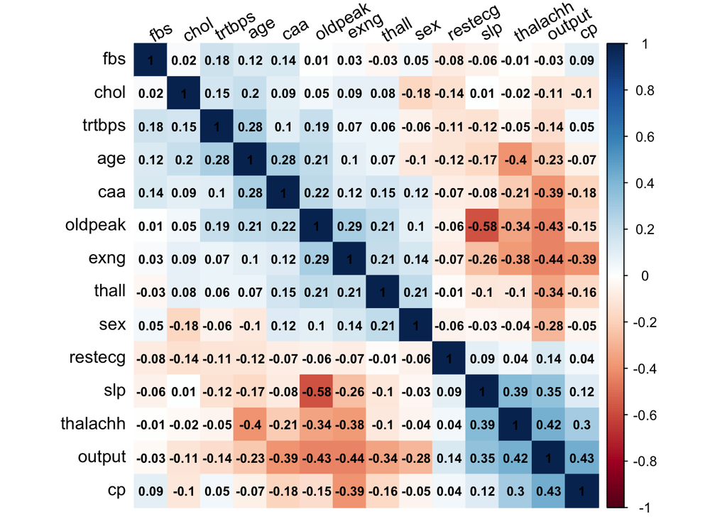

```r
if(!require("corrplot")) install.packages("corrplot"); library("corrplot")
n = c("age","sex","cp","trtbps","chol","fbs","restecg","thalachh","exng","oldpeak","slp","caa","thall","output")
factors= heartData %>% select(all_of(n))
res<-cor(factors)
corrplot(res,method="color",tl.col="black", tl.srt=30, order = "AOE",
   number.cex=0.75,sig.level = 0.01, addCoef.col = "black")
```

Aquí podem veure la matriu de confusió per veure les correlacions entre atributs. Observem que la correlació més alta és entre els atributs slp i oldpeak amb un valor de -0,58. Pel que fa la variable objectiu veiem com atributs com cp, slp, sex, thall, exng entre d’altres, tenen molt bona correlació i són els que utilitzarem per veure com es distribueix la variable objectiu.

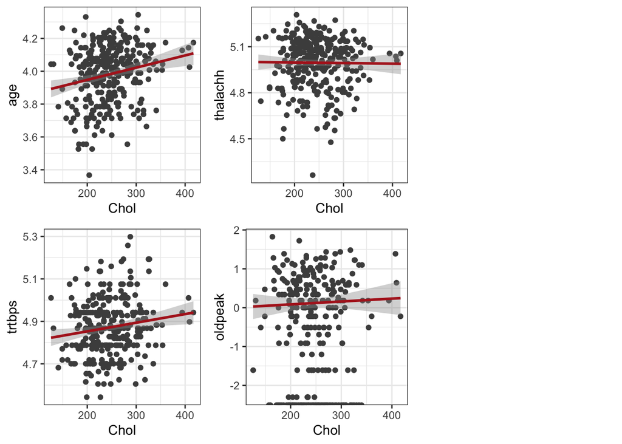

```r
# Utilitzem aquesta llibreria per fer servir la funcio multiplot()
if(!require('Rmisc')) install.packages('Rmisc'); library('Rmisc')
#Crearem primer una llista per mostrar les gràfiques de correlacions
#Crearem una llista per mostrar els atributs que interessen.


n = c("age","trtbps","thalachh","oldpeak")
accidentDataRegression = heartData %>% select(all_of(n))
histList2<- vector('list', ncol(accidentDataRegression))
for(i in seq_along(accidentDataRegression)){
  message(i)
histList2[[i]]<-local({
  i<-i
  col <-log(accidentDataRegression[[i]])
  ggp<- ggplot(data = accidentDataRegression, aes(x = heartData$chol, y=col)) +
    geom_point(color = "gray30") + geom_smooth(method = lm,color = "firebrick") +
    theme_bw() + xlab("Chol") + ylab(names(accidentDataRegression)[i])
  })

}
multiplot(plotlist = histList2, cols = 3)
```

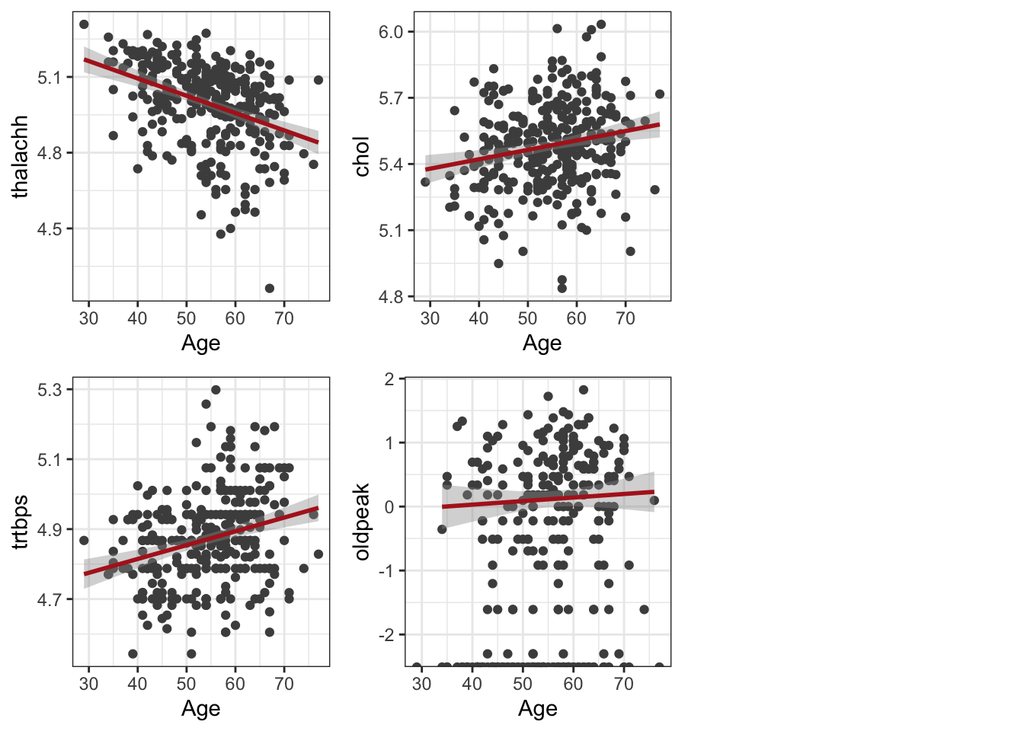

```r
n = c("thalachh","trtbps","chol","oldpeak")
accidentDataRegression = heartData %>% select(all_of(n))
histList2<- vector('list', ncol(accidentDataRegression))
for(i in seq_along(accidentDataRegression)){
  message(i)
histList2[[i]]<-local({
  i<-i
  col <-log(accidentDataRegression[[i]])
  ggp<- ggplot(data = accidentDataRegression, aes(x = heartData$age, y=col)) +
    geom_point(color = "gray30") + geom_smooth(method = lm,color = "firebrick") +
    theme_bw() + xlab("Age") + ylab(names(accidentDataRegression)[i])
  })

}
multiplot(plotlist = histList2, cols = 3)
```

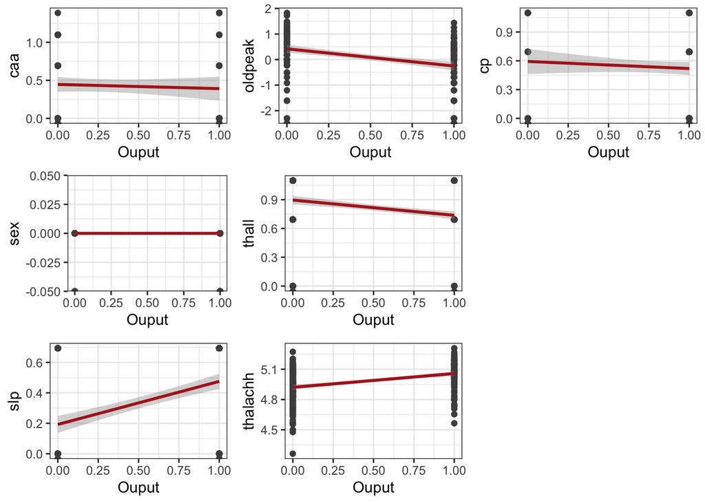

```r
n = c("caa","sex","slp","oldpeak","thall","thalachh","cp")
accidentDataRegression = heartData %>% select(all_of(n))
histList2<- vector('list', ncol(accidentDataRegression))
for(i in seq_along(accidentDataRegression)){
  message(i)
histList2[[i]]<-local({
  i<-i
  col <-log(accidentDataRegression[[i]])
  ggp<- ggplot(data = accidentDataRegression, aes(x = heartData$output, y=col)) +
    geom_point(color = "gray30") + geom_smooth(method = lm,color = "firebrick") +
    theme_bw() + xlab("Ouput") + ylab(names(accidentDataRegression)[i])
  })

}
multiplot(plotlist = histList2, cols = 3)
```

Podem veure que les regression entres dades no categoriques podem veure la majoria dels registres. Pel que fa el colesterol veiem que la millore regressió la obté amb l’atribut de l’edat la millor regressió amb l’atribut de la talassemia.

Per veure les regressions amb dades catgoriques podem veure que no es veu tan be. Com per exemple la variable objectiu. Bàsicament perque el eix x només te 2 valors i aixo fa que la majoria dels punts quedin amagats. No són tan visuals.

Anem a veure la variable objectiu.

```r
path = 'heart.CSV'
factorData <- read.csv(path, row.names=NULL)
factorData[] <- lapply(factorData, factor)
str(factorData)
```

```
## 'data.frame':    303 obs. of  14 variables:
##  $ age     : Factor w/ 41 levels "29","34","35",..: 30 4 8 23 24 24 23 11 19 24 ...
##  $ sex     : Factor w/ 2 levels "0","1": 2 2 1 2 1 2 1 2 2 2 ...
##  $ cp      : Factor w/ 4 levels "0","1","2","3": 4 3 2 2 1 1 2 2 3 3 ...
##  $ trtbps  : Factor w/ 49 levels "94","100","101",..: 32 23 23 15 15 29 29 15 44 35 ...
##  $ chol    : Factor w/ 152 levels "126","131","141",..: 65 81 36 68 146 26 117 93 32 10 ...
##  $ fbs     : Factor w/ 2 levels "0","1": 2 1 1 1 1 1 1 1 2 1 ...
##  $ restecg : Factor w/ 3 levels "0","1","2": 1 2 1 2 2 2 1 2 2 2 ...
##  $ thalachh: Factor w/ 91 levels "71","88","90",..: 50 85 72 77 63 48 53 73 62 74 ...
##  $ exng    : Factor w/ 2 levels "0","1": 1 1 1 1 2 1 1 1 1 1 ...
##  $ oldpeak : Factor w/ 40 levels "0","0.1","0.2",..: 23 33 15 9 7 5 14 1 6 17 ...
##  $ slp     : Factor w/ 3 levels "0","1","2": 1 1 3 3 3 2 2 3 3 3 ...
##  $ caa     : Factor w/ 5 levels "0","1","2","3",..: 1 1 1 1 1 1 1 1 1 1 ...
##  $ thall   : Factor w/ 4 levels "0","1","2","3": 2 3 3 3 3 2 3 4 4 3 ...
##  $ output  : Factor w/ 2 levels "0","1": 2 2 2 2 2 2 2 2 2 2 ...
```

```r
df1 <- factorData %>%
  group_by(factorData$output) %>%
  dplyr::summarise(counts = n())
df1
```

| factorData$output | counts |
| --- | --- |
| 0 | 138 |
| 1 | 165 |

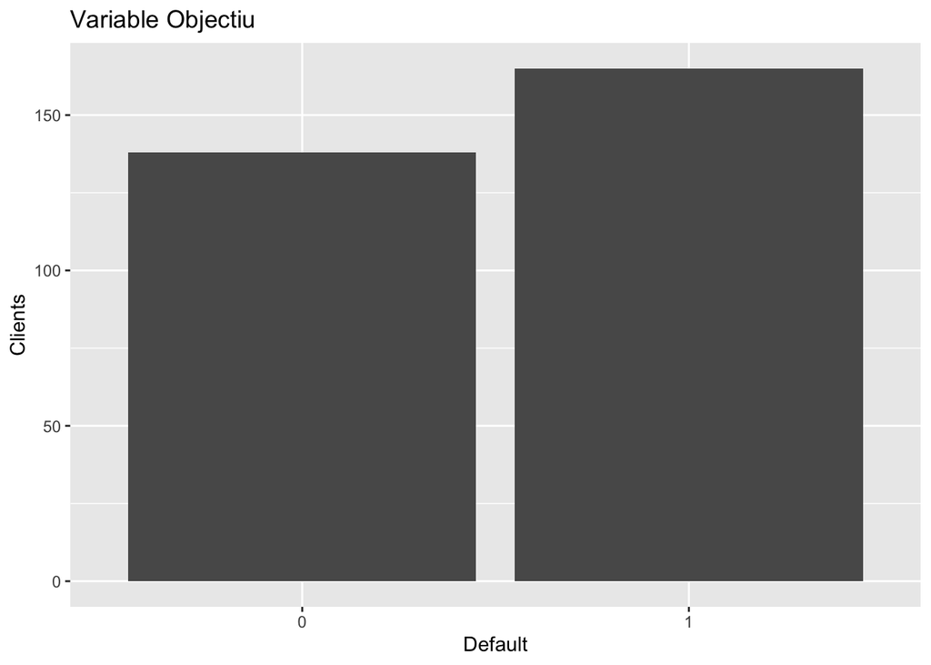

```r
plotbyDefault<-ggplot(factorData,aes(output))+geom_bar() +labs(x="Default", y="Clients")+ guides(fill=guide_legend(title=""))+ scale_fill_manual(values=c("blue","#008000"))+ggtitle("Variable Objectiu")
grid.arrange(plotbyDefault)
```

Observem que de la variable objectiu tenim més mostres de persones amb possibilitat d’un atac cardiac que no. Veiem que els dos conjunts eestàn bastant igualats. Lo interessant d’aixó és que tenim un problema binari equilibrat, d’aquesta manera mesures de rendiment dels models com l’exactitud no porten confusió, en canvi, en problemes binaris no equilibrats si.

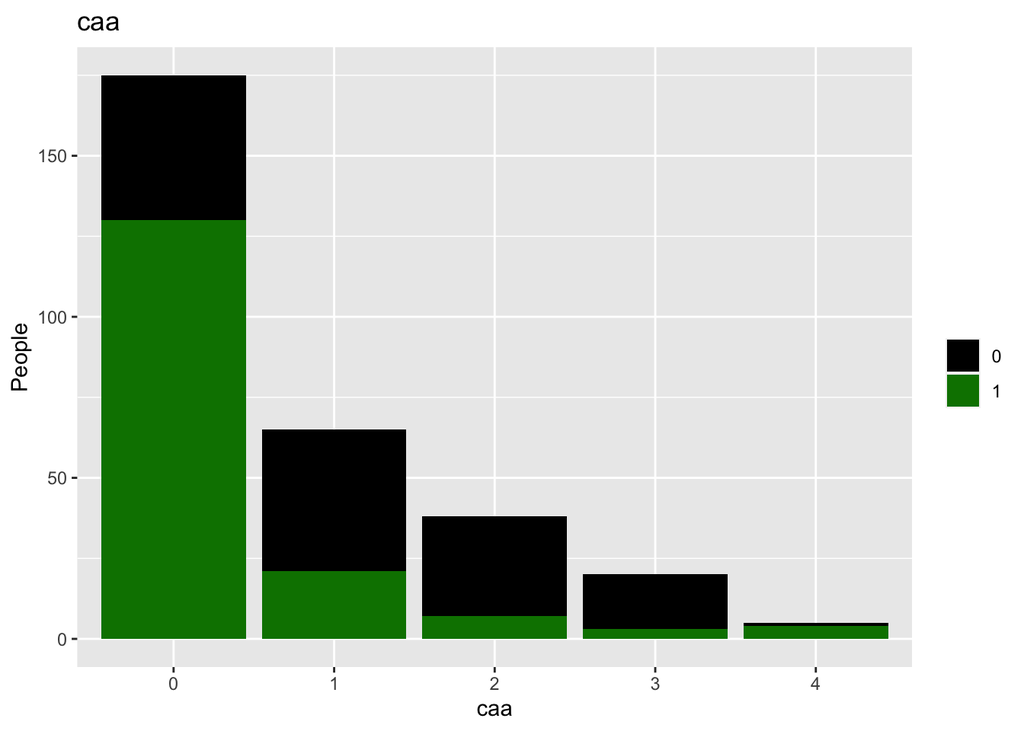

```r
plotbyCaa<-ggplot(factorData,aes(caa,fill=output))+geom_bar() +labs(x="caa", y="People")+ guides(fill=guide_legend(title=""))+ scale_fill_manual(values=c("black","#008000"))+ggtitle("caa")
plotbyOldpeak<-ggplot(factorData,aes(oldpeak,fill=output))+geom_bar() +labs(x="oldpeak", y="People")+ guides(fill=guide_legend(title=""))+ scale_fill_manual(values=c("black","#008000"))+ggtitle("oldpeak")
plotbyThall<-ggplot(factorData,aes(thall,fill=output))+geom_bar() +labs(x="thall", y="People")+ guides(fill=guide_legend(title=""))+ scale_fill_manual(values=c("black","#008000"))+ggtitle("thall")
plotbySlp<-ggplot(factorData,aes(slp,fill=output))+geom_bar() +labs(x="slp", y="People")+ guides(fill=guide_legend(title=""))+ scale_fill_manual(values=c("black","#008000"))+ggtitle("slp")
plotbySex<-ggplot(factorData,aes(sex,fill=output))+geom_bar() +labs(x="sex", y="People")+ guides(fill=guide_legend(title=""))+ scale_fill_manual(values=c("black","#008000"))+ggtitle("sex")
plotbyThalachh<-ggplot(factorData,aes(thalachh,fill=output))+geom_bar() +labs(x="thalachh", y="People")+ guides(fill=guide_legend(title=""))+ scale_fill_manual(values=c("black","#008000"))+ggtitle("thalachh")
plotbyCp<-ggplot(factorData,aes(cp,fill=output))+geom_bar() +labs(x="cp", y="People")+ guides(fill=guide_legend(title=""))+ scale_fill_manual(values=c("black","#008000"))+ggtitle("cp")
plotbyAge<-ggplot(factorData,aes(age,fill=output))+geom_bar() +labs(x="age", y="People")+ guides(fill=guide_legend(title=""))+ scale_fill_manual(values=c("black","#008000"))+ggtitle("age")
grid.arrange(plotbyCaa)
```

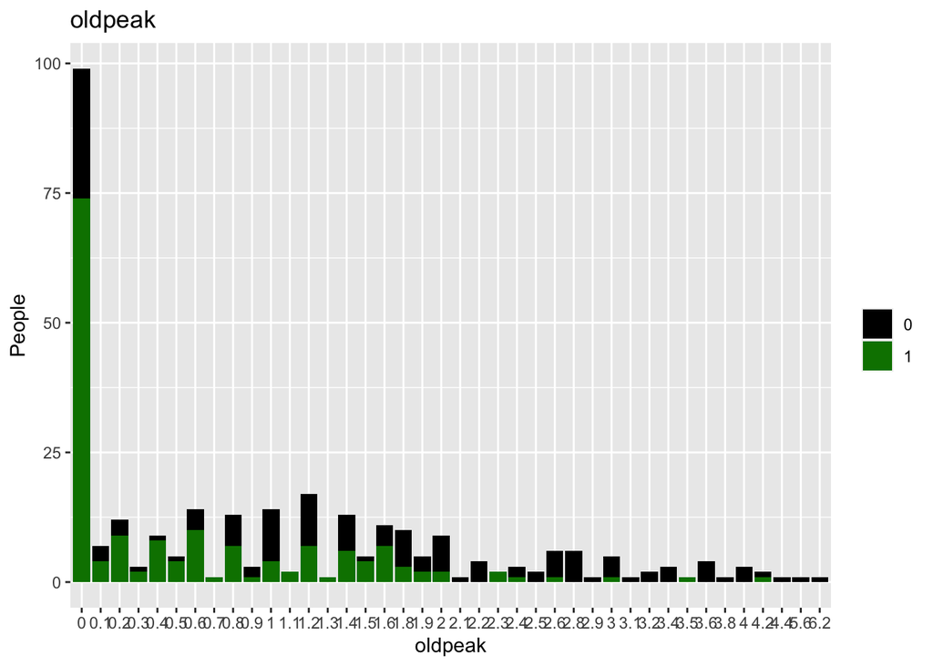

```r
grid.arrange(plotbyOldpeak)
```

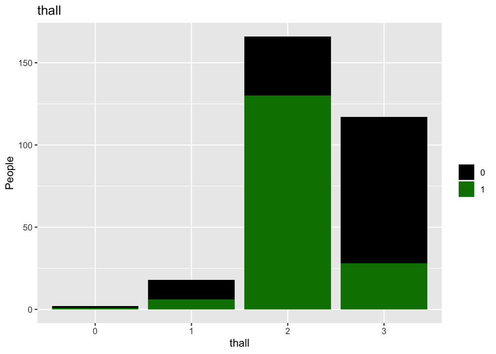

```r
grid.arrange(plotbyThall)
```

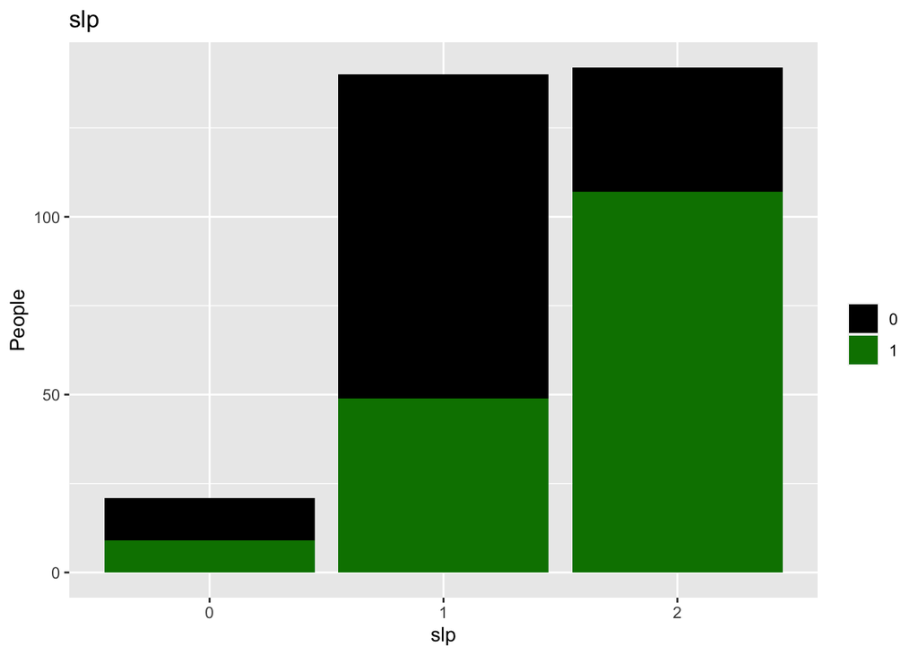

```r
grid.arrange(plotbySlp)
```

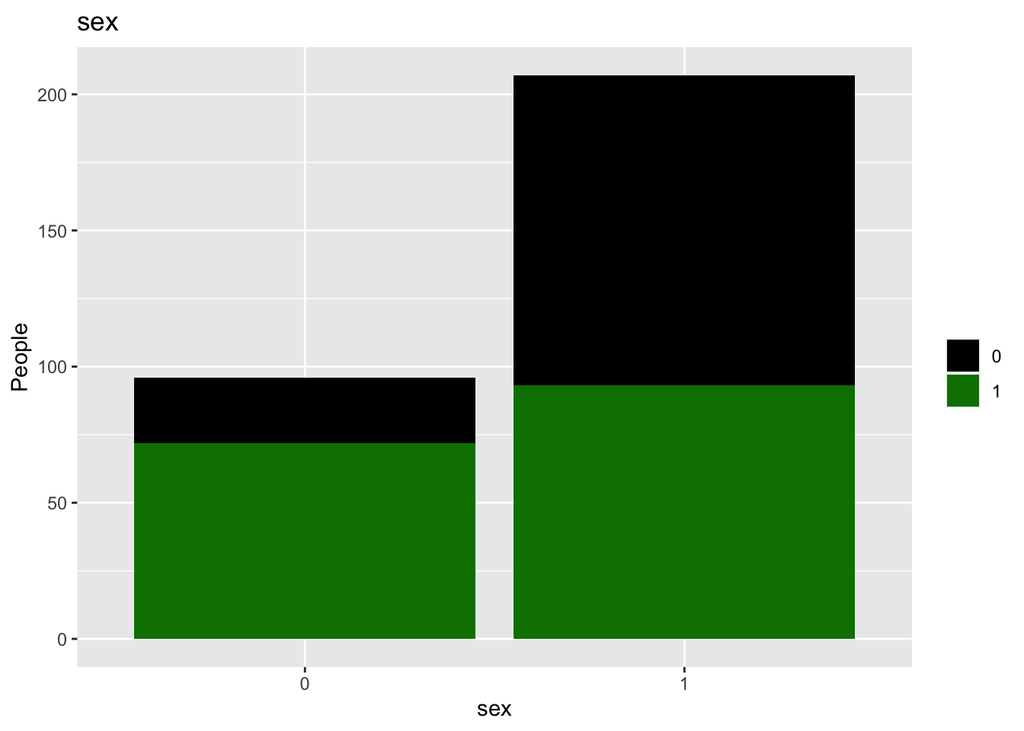

```r
grid.arrange(plotbySex)
```

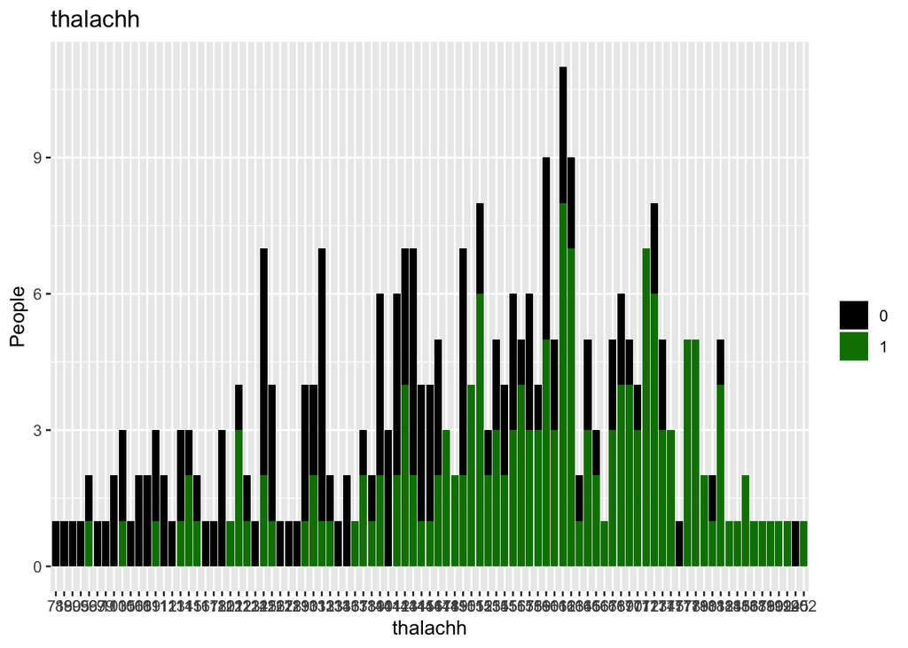

```r
grid.arrange(plotbyThalachh)
```

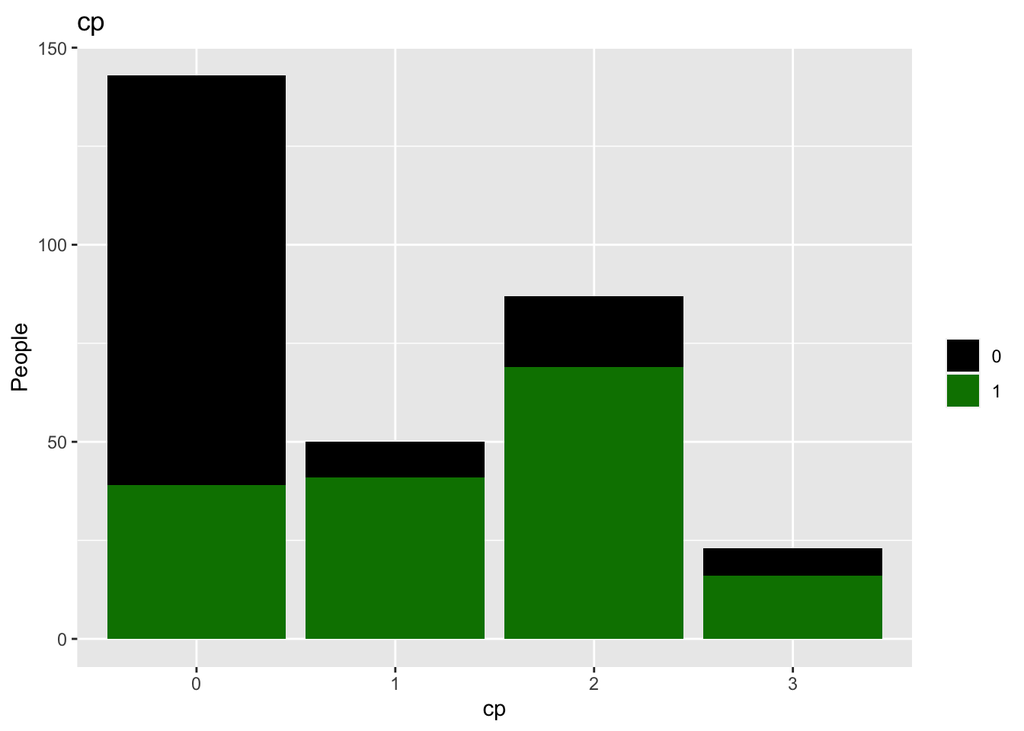

```r
grid.arrange(plotbyCp)
```

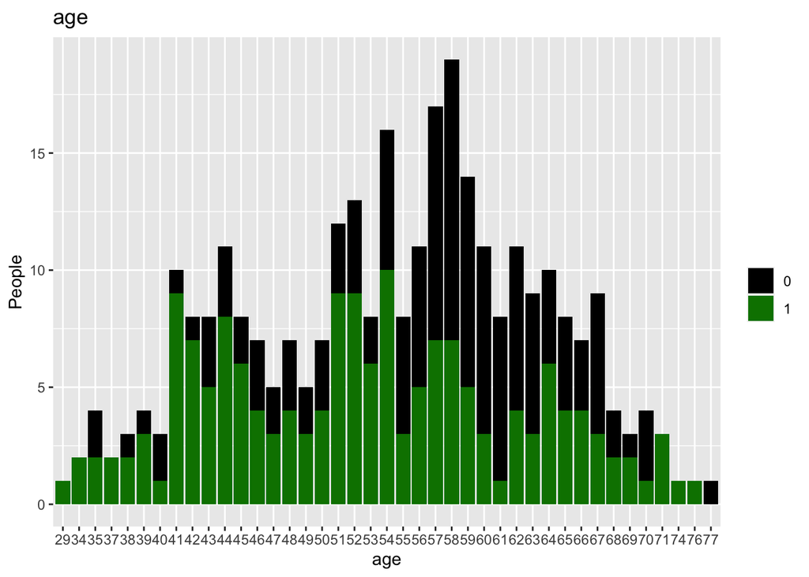

```r
grid.arrange(plotbyAge)
```

En aquests gràfics podem veure els valors que predominen en la variable objectiu dels atributs que tenen més correlació. Si algun gràfic no queda clar podem fer una taula de resultats.

```r
tabla_DMT <- table( heartData$output,heartData$caa)
tabla_DMT
```

```
##
##       0   1   2   3   4
##   0  45  44  31  17   1
##   1 130  21   7   3   4
```

Per al primer cas que relacionem el nombre de vasos majors veiem que a mesura que augmenta el número la probabilitat de no patir un atac és major, però si quan és igual a 4 augmenta molt les possibilitats de patir-lo. Això pot ser que sigui així o potser és que hi ha poques dades i ha resultat que 4 de 5 ho tenien. Aquí veiem un clar exemple que com més mostres hi hagi més coneixement podem treure.

Per l’atribut de depressió del segment de l’electrocardiograma(oldpeak) veiem que la probabilitat és major de patir un atac si el valor és petit. Veiem que la majoria de casos passen quan oldpeak és menor a 2.2.

Per l’atribut talassèmia veiem que l’etiqueta amb més risc correspon quan és 2 que equival quan la sang és normal. És estrany perquè és superior a 3 el qual equival a defecte reversible, és a dir, que s’observa flux sanguini, però no és normal. Llavors aquesta dada si apliquem sentit comú sembla que alguna cosa falli. Aquestes dades les intento tractar-les amb més precaució o fer altres proves que corroborin aquest fet.

En aquest cas he mirat un altre lloc i efectivament estava malament. Com sabíem l’atribut és talassèmia que bàsicament és una malaltia hereditària que afecta la creació de globus vermells i a l’hemoglobina del cos. Llavors l’etiqueta 2, ens parla del defecte permanent de la producció de globus vermells (anèmia) i que evidentment significa un gran impacte per la salut i el benestar del pacient. Per altra banda, l’etiqueta 3 ens parla del mateix, però sent reversible, és a dir, que amb un tractament adequat, podem millorar i corregir el defecte augmentat la producció d’hemoglobina sana. Per tant, ara sí que té sentit que l’etiqueta 2 sigui la més probable de patir un atac cardíac.

Per l’atribut slp veiem que és més probable patir un atac si el pendent del segment de l’exercici màxim és positiva.

Per l’atribut gènere veiem que és molt més probable que pateixi un atac cardíac les dones que els homes. Una dada impactant. Aquí podríem fer un estudi paral·lel de buscar el motiu. Veure si és un tema del cos que funciona diferent, si és perquè fan menys exercici, etc.

Buscant informació en una altra pàgina m’ha sortit que era el revés l’etiquetatge. Que 0 eren els homes i 1 les dones. Llavors seria el revés. En definitiva l’etiqueta 0 és més probable que tingui un atac cardíac. Crec que no costa res que en la descripció del kaggle si hi ha un atribut categòric que menciones a què correspon cada categoria i no un simple “Sex : Sex of the patient”. Dona molt poc coneixement.

Per l’atribut de freqüència cardíaca màxima veiem que com més alta més probabilitat de patir un atac cardíac.

Per l’atribut cp observem que si tens dolor al pit, sigui quin sigui el tipus és més probable de patir un atac cardíac.

Per l’atribut edat que potser més d’un diria que com més gran més possibilitat de patir un atac cardíac les dades ens diuen, que no té per què. Inclús sembla que com més petit més probabilitat de patir un atac cardíac. També és veritat que com més jove ets també fas més esport.

Gràcies a aquests estudis hem pogut resoldre a la pregunta: Quins factors de risc augmenten la probabilitat de patir un atac cardíac?

A continuació resoldrem la pregunta: És possible predir el risc de patir un atac cardíac? Per fer-ho aplicarem un algorisme de classificació.

El nostre objectiu és crear un arbre de decisió que permeti analitzar si una persona te risc de predir un atac cardíac.

```r
library(C50)

sample <- sample(203,100)
test <- heartData[sample,]
train <- heartData[-sample,]

aa <- heartData[sample,]
trainn <- factorData[-sample,]
model <- C5.0(train[-14],trainn$output,rules = TRUE)
summary(model)
```

```
##
## Call:
## C5.0.default(x = train[-14], y = trainn$output, rules = TRUE)
##
##
## C5.0 [Release 2.07 GPL Edition]      Fri Jan 13 23:35:05 2023
## -------------------------------
##
## Class specified by attribute `outcome'
##
## Read 203 cases (14 attributes) from undefined.data
##
## Rules:
##
## Rule 1: (27, lift 1.7)
##  restecg > 0
##  slp <= 1
##  thall > 2
##  ->  class 0  [0.966]
##
## Rule 2: (20, lift 1.6)
##  chol > 271
##  restecg <= 0
##  thall > 2
##  ->  class 0  [0.955]
##
## Rule 3: (64/4, lift 1.6)
##  cp <= 0
##  thall > 2
##  ->  class 0  [0.924]
##
## Rule 4: (6, lift 1.5)
##  exng > 0
##  thall <= 1
##  ->  class 0  [0.875]
##
## Rule 5: (10/1, lift 1.4)
##  sex <= 0
##  restecg > 0
##  exng > 0
```

[output cut: 75 more lines]

```
##  Attribute usage:
##
##   86.21% caa
##   74.88% thall
##   62.56% cp
##   37.44% slp
##   35.96% exng
##   32.02% restecg
##   21.18% sex
##   12.81% thalachh
##    9.85% chol
##    9.85% oldpeak
##
##
## Time: 0.0 secs
```

Observem que en els dos datasets train i test hi ha outputs 0 i 1. Aixó és important perquè no hi hagi un overfitting o un underfitting que faria predir potser molt be el dataset d’entrenament però al predir noves mostres no sortiria un bon model de predicció.

Veiem que a part de ser un algorisme de classificació també ens dona regles.Per tant, podem continuar responent a la pregunta: : Quins factors de risc augmenten la probabilitat de patir un atac cardíac?

```r
predicted_model <- predict( model, test[-14], type="class" )
class(predicted_model)
```

```
## [1] "factor"
```

```r
class(test[14])
```

```
## [1] "data.frame"
```

```r
test$output <- as.factor(test$output)
index = 1
pred = 0
for( i in test$output ){
  if(i == predicted_model[index]){
    pred = pred +1
  }
  index = index +1
}
print(sprintf("La precisión del árbol es: %.0f %%",pred))
```

```
## [1] "La precisión del árbol es: 85 %"
```

```r
heartDataNew<-read.csv("./heart.CSV",header=T,sep=",")
library(C50)


sample <- sample(203,100)
test <- heartDataNew[sample,]
train <- heartDataNew[-sample,]

train$output<-as.factor(train$output)
str(train)
```

```
## 'data.frame':    203 obs. of  14 variables:
##  $ age     : int  56 57 56 57 48 49 58 69 61 40 ...
##  $ sex     : int  1 0 0 1 0 1 0 0 1 1 ...
##  $ cp      : int  1 0 1 2 2 1 3 3 2 3 ...
##  $ trtbps  : int  120 120 140 150 130 130 150 140 150 140 ...
##  $ chol    : int  236 354 294 168 275 266 283 239 243 199 ...
##  $ fbs     : int  0 0 0 0 0 0 1 0 1 0 ...
##  $ restecg : int  1 1 0 1 1 1 0 1 1 1 ...
##  $ thalachh: int  178 163 153 174 139 171 162 151 137 178 ...
##  $ exng    : int  0 1 0 0 0 0 0 0 1 1 ...
##  $ oldpeak : num  0.8 0.6 1.3 1.6 0.2 0.6 1 1.8 1 1.4 ...
##  $ slp     : int  2 2 1 2 2 2 2 2 1 2 ...
##  $ caa     : int  0 0 0 0 0 0 0 2 0 0 ...
##  $ thall   : int  2 2 2 2 2 2 2 2 2 3 ...
##  $ output  : Factor w/ 2 levels "0","1": 2 2 2 2 2 2 2 2 2 2 ...
```

```r
model <- C5.0(train[-14],train$output,rules = TRUE)
summary(model)
```

```
##
## Call:
## C5.0.default(x = train[-14], y = train$output, rules = TRUE)
##
##
## C5.0 [Release 2.07 GPL Edition]      Fri Jan 13 23:35:05 2023
## -------------------------------
##
## Class specified by attribute `outcome'
##
## Read 203 cases (14 attributes) from undefined.data
##
## Rules:
##
## Rule 1: (68/1, lift 1.6)
##  cp <= 0
##  caa > 0
##  ->  class 0  [0.971]
##
## Rule 2: (32, lift 1.6)
##  oldpeak > 2.4
##  ->  class 0  [0.971]
##
## Rule 3: (31, lift 1.6)
##  restecg <= 0
##  caa > 1
##  ->  class 0  [0.970]
##
## Rule 4: (27/1, lift 1.5)
##  cp <= 0
##  trtbps > 115
##  restecg > 0
##  slp <= 1
##  ->  class 0  [0.931]
##
## Rule 5: (9, lift 1.5)
##  restecg <= 0
##  thalachh > 160
##  caa > 0
##  ->  class 0  [0.909]
```

[output cut: 70 more lines]

```
##
##
##  Attribute usage:
##
##   84.24% thall
##   68.47% caa
##   67.00% cp
##   62.56% restecg
##   37.44% oldpeak
##   26.60% trtbps
##   25.62% slp
##   18.23% thalachh
##
##
## Time: 0.0 secs
```

```r
predicted_model <- predict( model, test[-14], type="class" )
class(predicted_model)
```

```
## [1] "factor"
```

```r
class(test[14])
```

```
## [1] "data.frame"
```

```r
test$output <- as.factor(test$output)
index = 1
pred = 0
for( i in test$output ){
  if(i == predicted_model[index]){
    pred = pred +1
  }
  index = index +1
}
print(sprintf("La precisión del árbol es: %.0f %%",pred))
```

```
## [1] "La precisión del árbol es: 81 %"
```